# Pace Count Analysis

Purpose: (1) review key insights and supporting data visualizations; (2) discuss a project way-ahead.

## Sample Summary

Study sample size: Females n=55; Males n=271; ~1,500 observations.

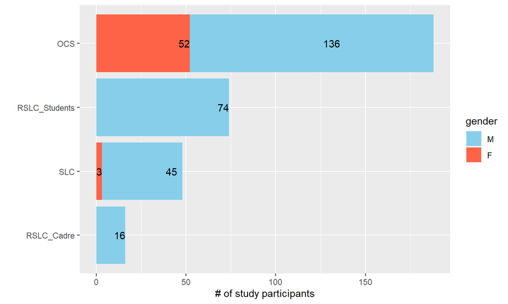

## Key Findings (1 of 2)

- *At Night* condition has a marked impact on pace count (approx. +4 steps for advanced trainees and +10 steps for beginners).
- *Height* displays a moderate negative correlation with pace count (-0.4), suggesting an impact from stride length.
- *Load/Ruck weight* has a marked impact to pace count (~ +4 steps from comparable noload conditions); ruck weights over 35 lbs having increasing impact.
- *Duration* appears to be a proxy measure for *experience*; lower duration, especially at night, suggests greater experience and generally lower pace counts.

## Key Findings (2 of 2)

- *Gender* appears to have an impact on pace count, though multi-collinearity with height and “experience” reduces the information gain from this feature.
- *Soldier Weight* strongly correlates with height and has negligible information gain for predicting pace count.
- *Night Vision Goggles* may contribute to a minor reduction (~ -2 steps) in pace counts at night, when compared to trainees without NVGs. This finding requires further exploration to determine if experience of RSLC Students is confounding.
- *For further exploration:* 20% (52/259) record lower pace counts under load, generally at night.

## Correlation plot

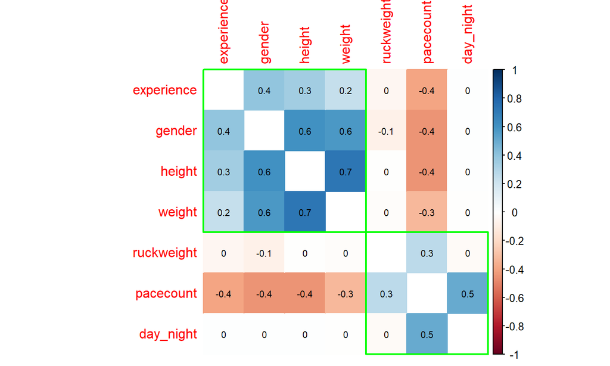

## Day/Night & Solider Height

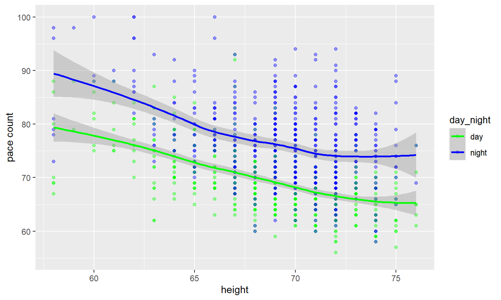

## Load (1 of 2)

- points above dashed line represent pace count *increase*

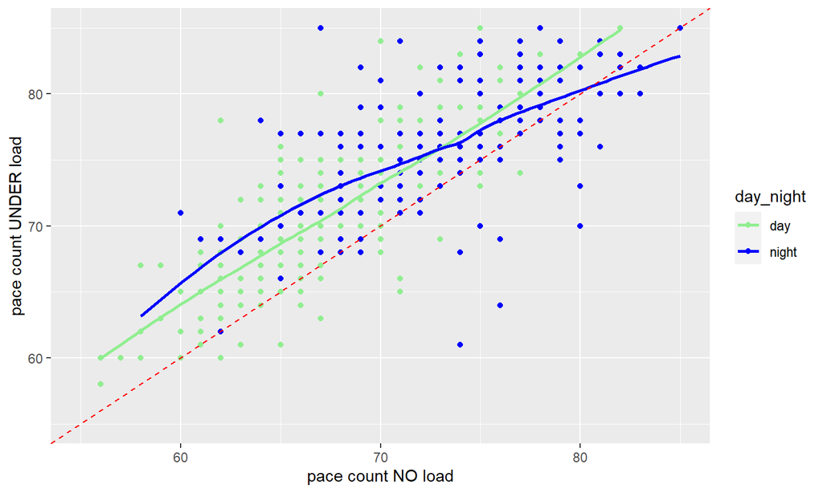

## Load (2 of 2)

RSLC Student average ruck = 25 lbs; OCS average ruck = 50 lbs.

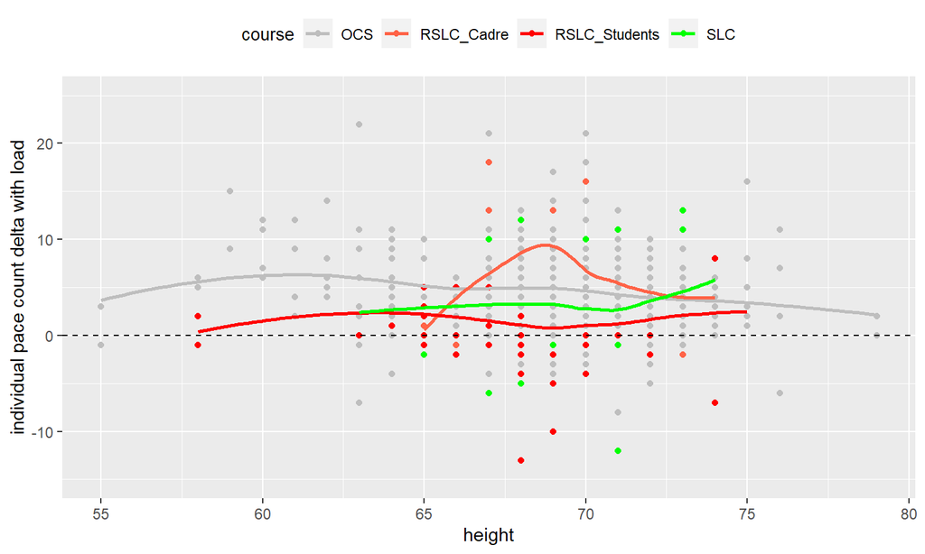

## Ruck Weight

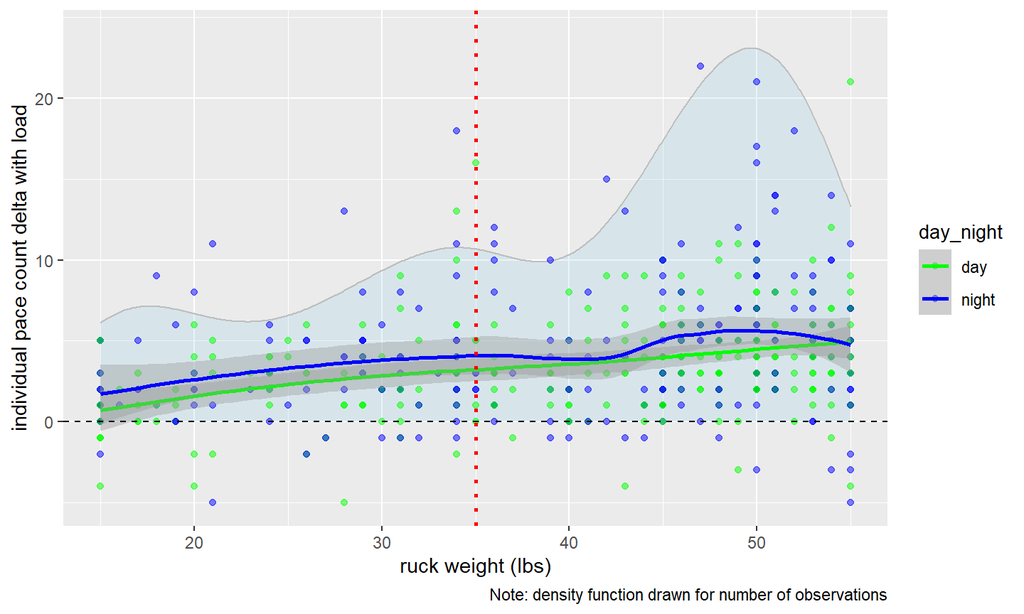

## Duration (1 of 4)

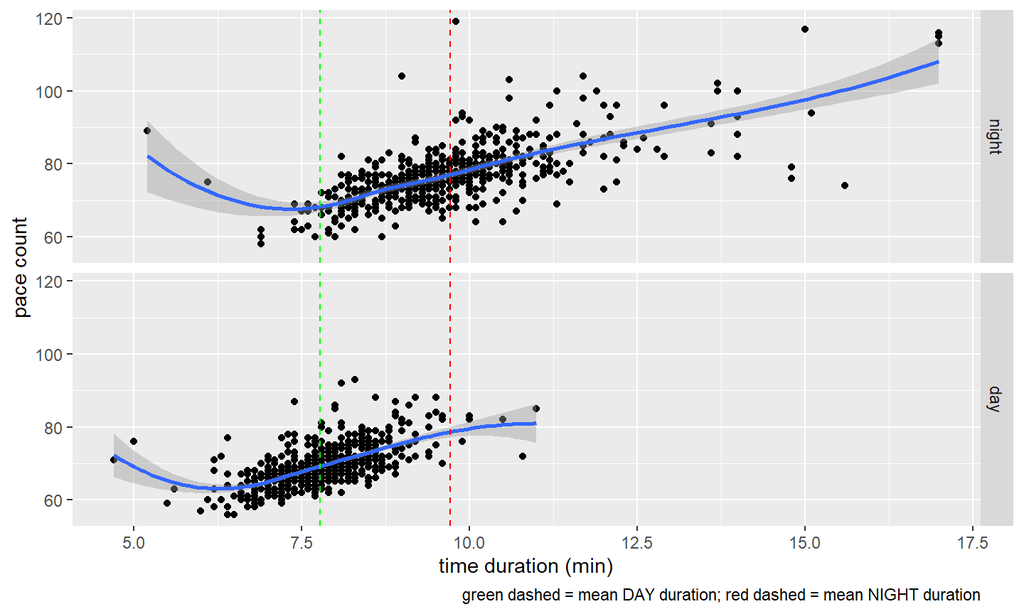

## Duration (2 of 4)

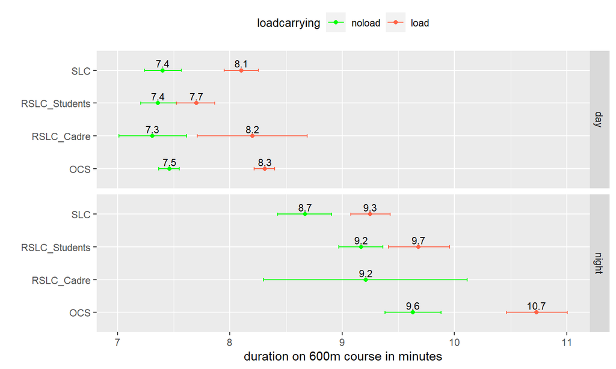

## Duration (3 of 4)

Duration used to inform a dummy variable for experience.

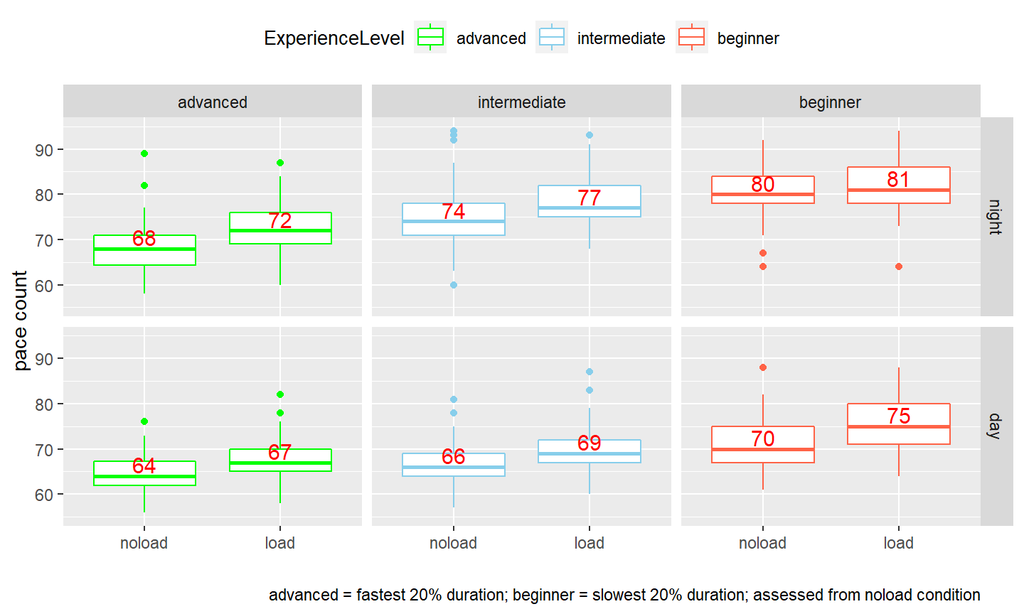

## Duration (4 of 4)

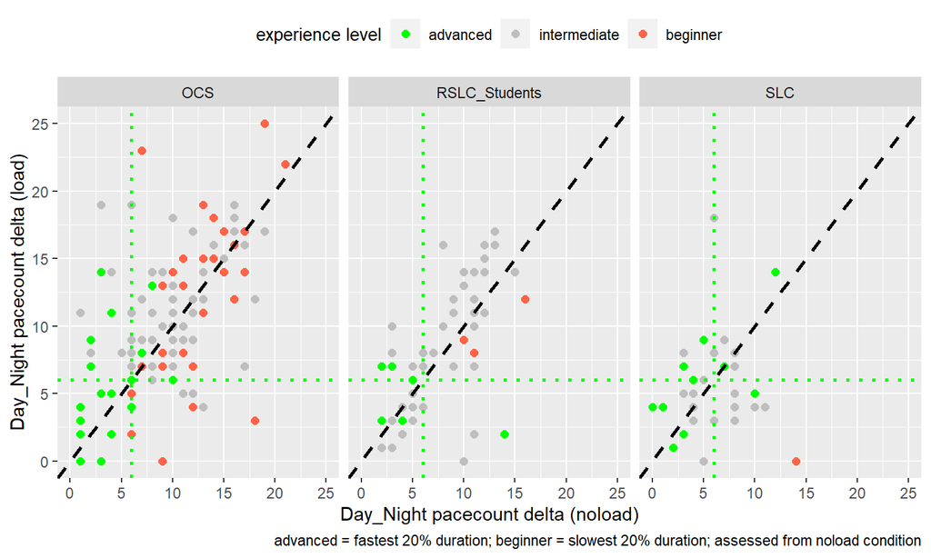

## Gender

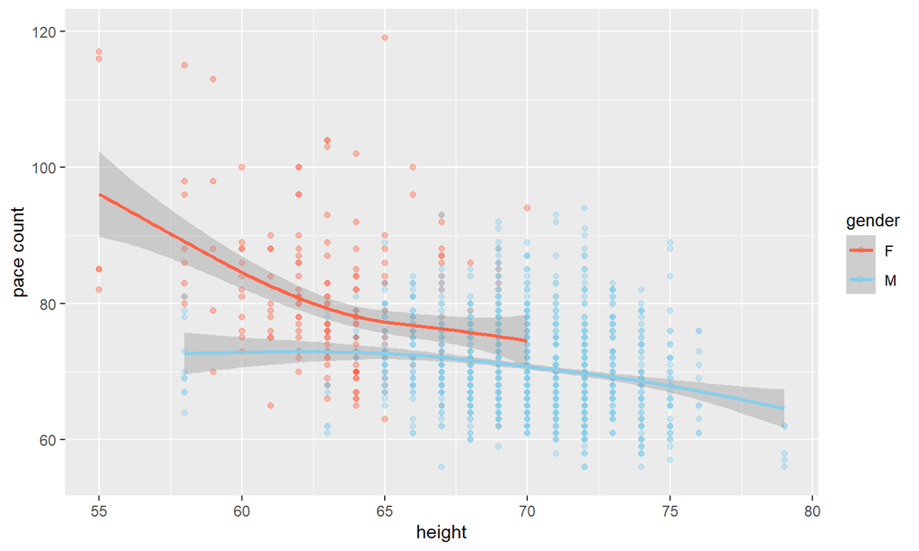

## Solider Weight

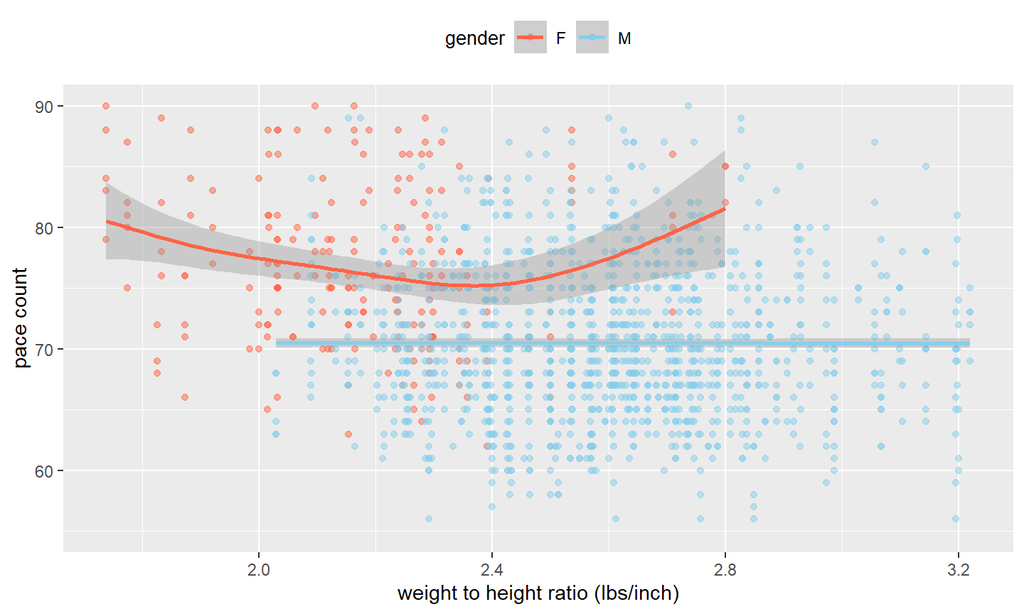

## Night Vision

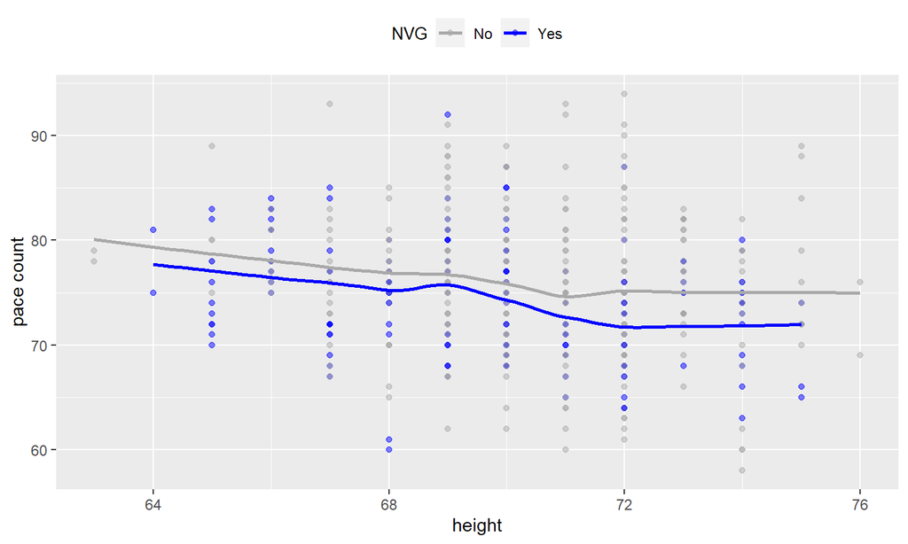

## Precision

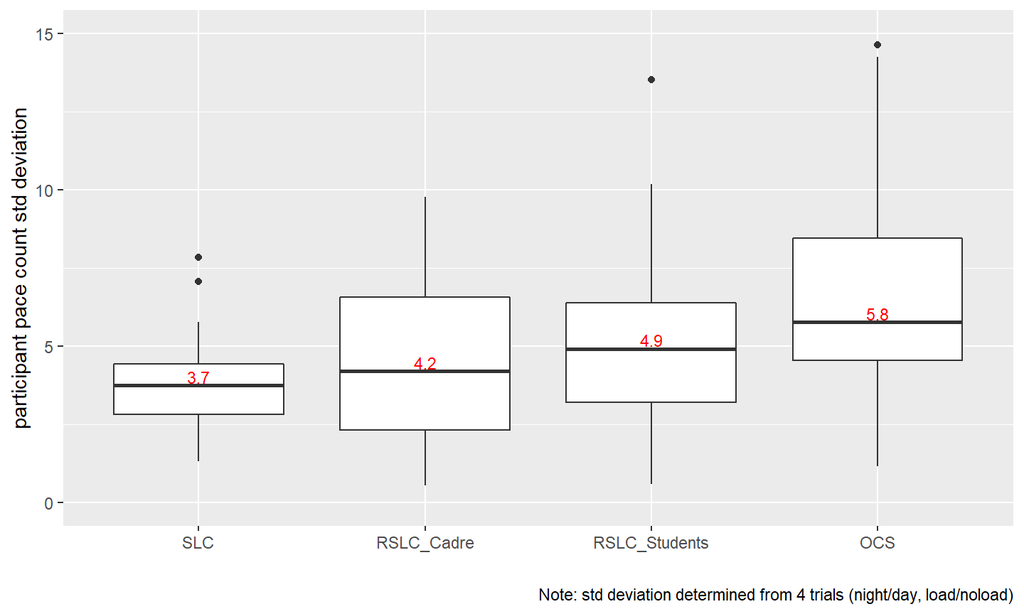

## What Matters (1 of 3)

### Multiple Linear Regression

*Essential Features (R2 = 0.535):*

- Day or Night Condition
- Soldier Height
- Load/Ruck weight or No load Condition

*Added Value (R2 = 0.597):*

- Experience (beginner/intermediate/advanced)

*Small Information Gain:*

- Gender (R2 = 0.614)
- Soldier Weight (R2 = 0.615)

## What Matters (2 of 3)

### Machine Learning (Regression Trees)

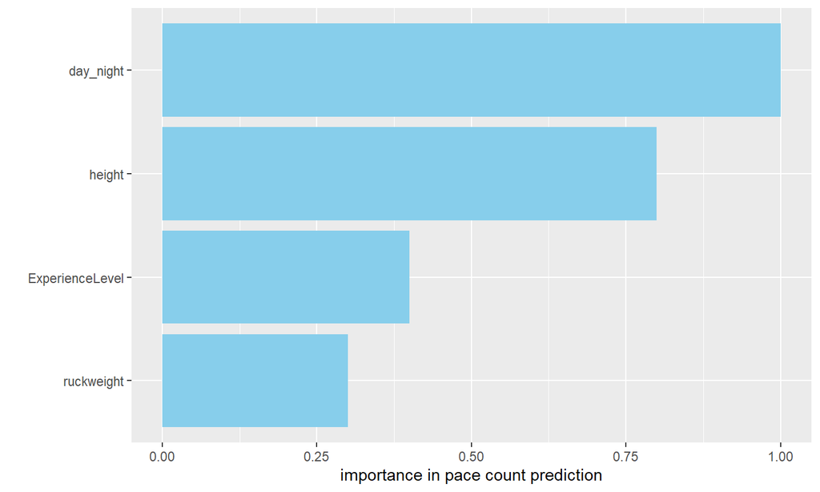

## What Matters (3 of 3)

### Machine Learning (Regression Trees)

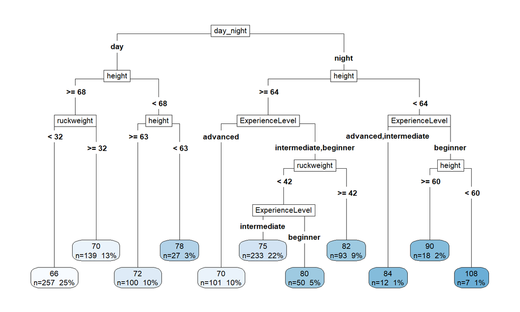

## Course Comparison (1 of 2)

Short (100m) vs. long (600m) course results: points expected near dashed line

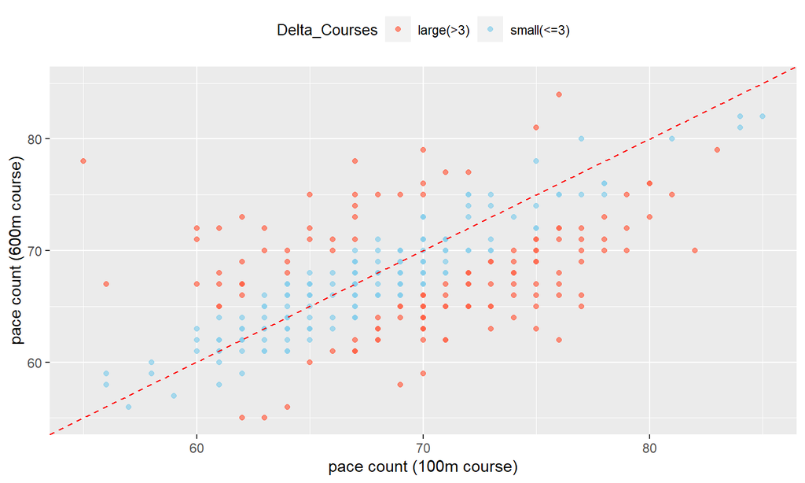

## Course Comparison (2 of 2)

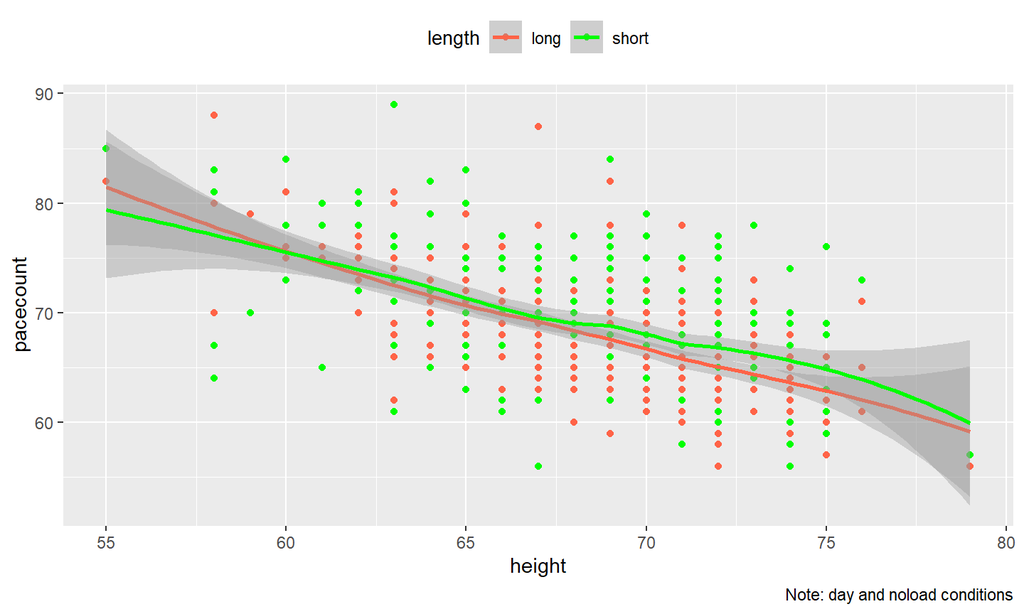

## Study Comparison

### Ranger/RSLC Land Nav vs. Pace Count Study

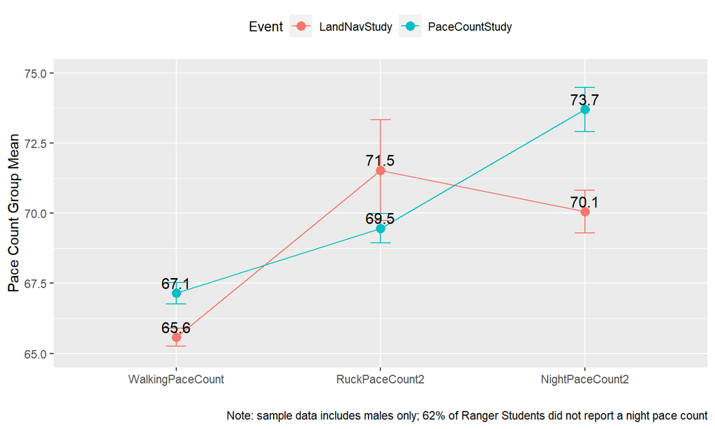

## Pace Count Table

Table available at:

https://github.com/mattdeloia/PaceCount_Analysis/blob/gh-pages/PaceCountTable(Final).png

Interactive Application (under development) at: https://mattdeloia.shinyapps.io/PaceCount_Estimator/

Notes:

- Advanced Navigators make the following adjustments at each no load and load pace count: (-2) steps to all Day ; (-5) steps to all Night.
- Beginner Navigators make the following adjustments at each no load and load pace count: +2 steps to all Day; +5 steps to all Night.

## Way-Ahead

Transition key findings for doctrine and POI/lesson plans (DOTD brief):

- Utility of a 600M cross-country pace count course
- Day versus night pace counts
- Effect of load on pace counts
- Other considerations- NVDs, thick vegetation, weather
- Pace count estimator app?

Article submission on Dead Reckoning with results from future *Drift Course Study.*